# Lab 2

gmv5137

2023-09-26

# Lab Set Up

**What is an R project?**

An R project is a means in which you can organize work into one folder. It allows all corresponding files to be bundles together for both ease of access and easier sharing among peers. The following image shows both that the project file for Lab 2 is labelled correctly, currently opened on R Studio as well as placed in a corresponding Lab 2 folder

[figure not shown]

## Load libraries/apps

```r
 library(sp)
 library(sf)
 library(tmap)
 library(tidyverse)
 library(readxl)
#Added library for treemap#
 library(treemap)
```

# Frost Analysis

We are analyzing the average dates of last frost across the South Eastern United States collected from a study done from 1950 to 1999. We are looking for trends in both the time and locations of these dates to look for possible causes as well as its impact.

## Read in data

```r
frost <- read_excel("DataG364_frostday.xlsx")
```

## Analysis

```r
mean(frost$Dist_to_Coast)
```

```
## [1] 129.4375
```

The average distance to coast of weather stations participating in the study was 129.4375 miles.

```r
max(frost$Elevation)
```

```
## [1] 3333
```

The highest elevation of a weather station in the study is 3333 feet.

```r
sd(frost$Dist_to_Coast)
```

```
## [1] 80.47953
```

The standard deviation for the values of distance to coast is 80.47953.

```r
table(frost$State)
```

```
##
## AL FL GA NC SC VA
##  6  6 19 21 20  4
```

A total of 6 of the weather stations that participated in this study were located in the state of Alabama

```r
summary(frost)
```

```
##    Station             State            Type_Fake         Avg_DOY_SpringFrost
##  Length:76          Length:76          Length:76          Min.   : 46.89
##  Class :character   Class :character   Class :character   1st Qu.: 83.92
##  Mode  :character   Mode  :character   Mode  :character   Median : 90.87
##                                                           Mean   : 89.44
##                                                           3rd Qu.: 98.78
##                                                           Max.   :118.29
##     Latitude       Longitude        Elevation      Dist_to_Coast
##  Min.   :28.80   Min.   :-86.82   Min.   :  10.0   Min.   :  1.148
##  1st Qu.:32.76   1st Qu.:-83.27   1st Qu.: 148.8   1st Qu.: 59.186
##  Median :34.23   Median :-81.98   Median : 485.0   Median :128.784
##  Mean   :33.91   Mean   :-81.84   Mean   : 569.7   Mean   :129.437
##  3rd Qu.:35.23   3rd Qu.:-80.22   3rd Qu.: 725.5   3rd Qu.:192.639
##  Max.   :37.33   Max.   :-76.55   Max.   :3333.0   Max.   :298.914
```

The summary command provides general information for each of the columns in the frost data set. For columns which cells contain characters it will only provide quantity of entries. For columns with numerical values it provides box plot values as well as the mean for each value.

```r
nrow(frost)
```

```
## [1] 76
```

Using the nrow command we can determine that there 76 weather stations in the study.

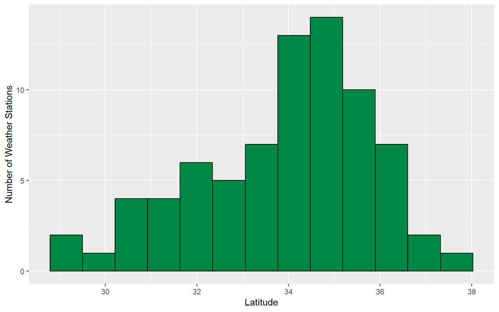

```r
#Code for Histogram changed color and increased value of bin#
ggplot(frost, aes(x=Latitude)) +
       geom_histogram(bins=13,
                      fill="#008744",
                      color="black")+
       ylab("Number of Weather Stations") +
       xlab("Latitude")
```

```r
#Added title changed from dots.col to symbols.col to change their size. Changed style to cobalt#
frost.spatial <- st_as_sf (frost,
                      coords =c("Longitude", "Latitude"),
                      crs = 4326)
tmap_mode('view')

qtm(frost.spatial,
    symbols.col='Avg_DOY_SpringFrost',
    symbols.size=2.5,
    title="Average Day of Last Frost",
    style="natural")
```

[interactive chart not shown]

As stated previously the goal of this study was to analyze the dates of last frost throughout the South Eastern United States to look for any trends and any possible causes of such trends. A total of 76 weather stations participated in the study casting a wide net around the region. The average last day of frost for the area studied was the 90th day of the year which is either the 30th or 31st of March depending on if its a leap year. The earliest date for last frost was recorded in Fernandina, FL on only the 46th day of the year while the latest was recorded in Marshall, NC on the 118th day of the year. From looking at the map we are able to see that as we look farther north and away from the coast last frost comes generally later in the year. A difference in time of frost based on distance from the Equator is not particularly shocking as more northern areas tend to have cooler climates. The more interesting trend is in relation to distance from the coast. This is likely due to the process of ocean waters interacting with the air around it, acting as an insulator and preventing against extreme heats and colds.

# UFO Analysis

## Read in data

```r
ufo <- st_read("gmv5137_UFO_Mexico")
```

## Analysis

The data I am analyzing is a compiling of reported UFO sightings in Mexico by the National UFO Reporting Center. The reported sighting start in June 1944 and end in March of 2014. There are a total of 219 sightings recorded in this data set. A likely spatial pattern that I hypothesize will appear is a high concentration of UFO sightings around areas of high air traffic either in urban areas or military installations likely also predominately occurring at night.

```r
#determining total of sighting in dataset#
nrow(ufo)
```

```
## [1] 219
```

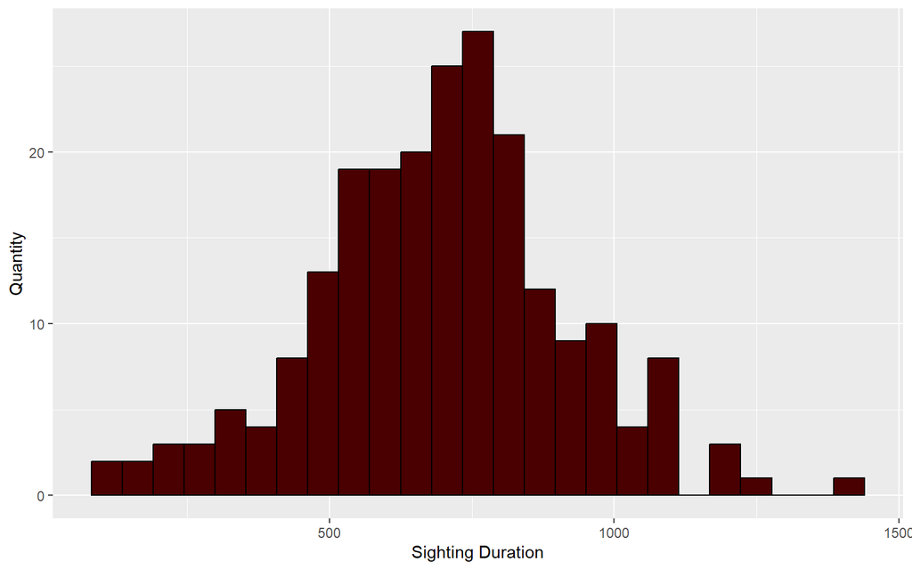

```r
#Histogram#
ggplot(ufo, aes(x=Sighting_Duration)) +
       geom_histogram(bins=25,
                      fill="#4A0000",
                      color="black")+
       ylab("Quantity") +
       xlab("Sighting Duration")
```

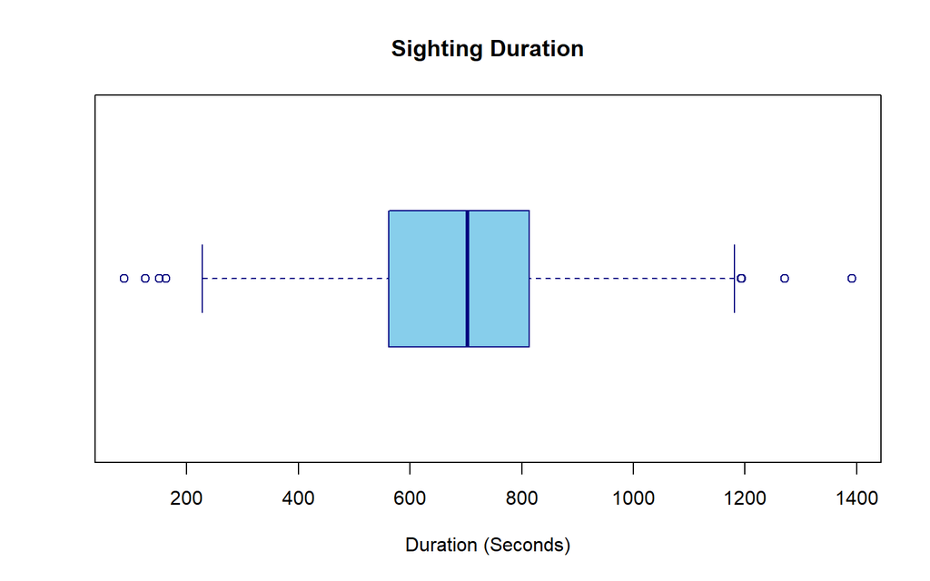

```r
#boxplot total#
boxplot(ufo$Sighting_Duration,
    main ="Sighting Duration",
    xlab="Duration (Seconds)",
    col="skyblue",
    border="navy",
    horizontal = T
)
```

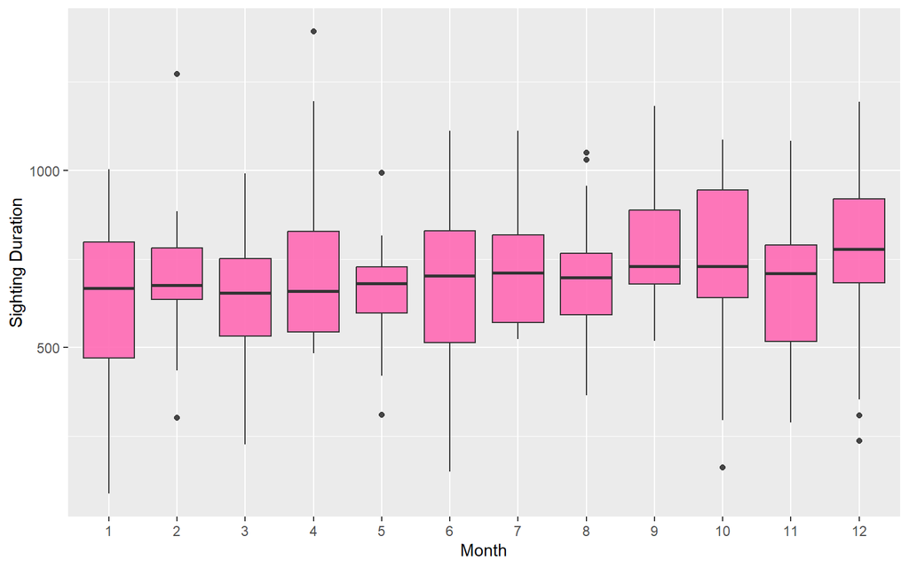

```r
#boxplot of each month#
ggplot(ufo, aes(x=as.factor(Month), y=Sighting_Duration)) +
    geom_boxplot(fill="hotpink", alpha=0.9) +
    xlab("Month") +
    ylab("Sighting Duration")
```

```r
#frequency table#
table(ufo$Sighting_Type)
```

```
##
##  changing   chevron     cigar    circle      cone     cross  cylinder   diamond
##         6         3         7        21         1         3         3         4
##      disk       egg  fireball     flash formation     light     other      oval
##        20         5         8         2         8        49        19        14
## rectangle    sphere  triangle   unknown
##         2        25        11         8
```

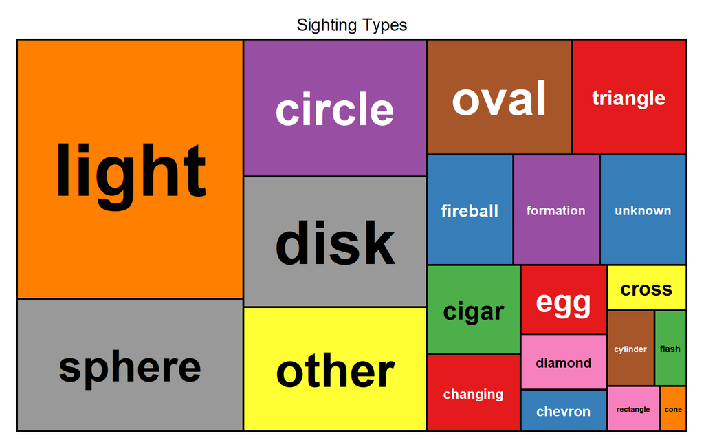

```r
#treemap#
ufo_treemap <- data.frame(
  group = ufo$Sighting_Type,
  value = nrow(ufo)
)


treemap(ufo_treemap,
        index = "group",
        vSize = "value",
        draw = TRUE,
        title = "Sighting Types",
        palette= "Set1",
        fontsize.labels = 7,
        overlap.labels = 1,
        inflate.labels = TRUE
)
```

```r
#MAP#
ufo.spatial <- st_as_sf(ufo, coords = c("geom"), crs = 4326)

tmap_mode("view")

qtm(ufo.spatial,
    symbols.col='Hour',
    symbols.size=2,
    title="Time of Sighting",
    style="natural"
    )
```

[interactive chart not shown]

As predicted the timing of the recorded UFO sightings is predominately at night. The majority of the sightings as seen on the above map is between 20:00-05:00 which is the time between sunset and sunrise. This is logical as at night visibility is significantly lower and it becomes easy to misinterpret things that in daylight would be easily identifiable. Additionally we see that the highest concentration of sightings is in and around Mexico city an area that has a high amount of air traffic which means more opportunities for someone to misidentify a commercial airliner.